# R Workshop

### Exploratory Analysis

If you are given data without a research question then you may have to scratch around to see if something fits.

Let’s use the formula for static pulmonary compliance on our data set.

$$\ C _{stat} = \frac{V_t}{P _{plateau} - PEEP}$$

```r
attach(all.vent.data)
all.vent.data$Cstat <- TidalVol.ml / (PlateauPress - PEEP.cmH20)
detach(all.vent.data)
# don't forget to check that all looks ok
head(all.vent.data)
```

|  | Hospital_No | Ventilator.hour | PlateauPress | PEEP.cmH20 | TidalVol.ml | index | Sex | Height | Weight | Cstat |
| --- | --- | --- | --- | --- | --- | --- | --- | --- | --- | --- |
| 9601 | F00008354 | 1 | 9 | 7 | 511 | 1 | Female | 165 | 74.3 | 255.500 |
| 9602 | F00008354 | 2 | 15 | 7 | 505 | 1 | Female | 165 | 74.3 | 63.125 |
| 9603 | F00008354 | 3 | 11 | 10 | 472 | 1 | Female | 165 | 74.3 | 472.000 |
| 9604 | F00008354 | 4 | 15 | 10 | 491 | 1 | Female | 165 | 74.3 | 98.200 |
| 9605 | F00008354 | 5 | 11 | 10 | 493 | 1 | Female | 165 | 74.3 | 493.000 |
| 9606 | F00008354 | 6 | 17 | 7 | 496 | 1 | Female | 165 | 74.3 | 49.600 |

```r
summary(all.vent.data)
```

```
##     Hospital_No    Ventilator.hour  PlateauPress     PEEP.cmH20
##  F00001216:  150   Min.   :  1.0   Min.   : 5.00   Min.   : 0.000
##  F00001316:  150   1st Qu.: 38.0   1st Qu.:15.00   1st Qu.: 5.000
##  F00001425:  150   Median : 75.5   Median :25.00   Median : 5.000
##  F00001485:  150   Mean   : 75.5   Mean   :24.16   Mean   : 6.984
##  F00001572:  150   3rd Qu.:113.0   3rd Qu.:33.00   3rd Qu.:10.000
##  F00001591:  150   Max.   :150.0   Max.   :45.00   Max.   :22.000
##  (Other)  :29100
##   TidalVol.ml         index            Sex            Height
##  Min.   : 100.0   Min.   :  1.00   Female:13950   Min.   :120.0
##  1st Qu.: 412.0   1st Qu.: 50.75   Male  :16050   1st Qu.:147.8
##  Median : 490.0   Median :100.50                  Median :162.0
##  Mean   : 513.9   Mean   :100.50                  Mean   :161.5
##  3rd Qu.: 583.0   3rd Qu.:150.25                  3rd Qu.:174.0
##  Max.   :5724.0   Max.   :200.00                  Max.   :210.0
##
##      Weight           Cstat
##  Min.   : 40.80   Min.   :-1694.00
##  1st Qu.: 64.78   1st Qu.:   18.06
##  Median : 86.15   Median :   29.36
##  Mean   : 88.71   Mean   :     Inf
##  3rd Qu.:112.10   3rd Qu.:   56.25
##  Max.   :149.80   Max.   :     Inf
##
```

Oh dear we have negative Cstat values. This is embarassing and no longer worthy of publication.

This requires cleaning

- Find the bad values and remove them

Or we can try and figure our why it happened

- Visualise

We can do this with a histogram. This is done with the `hist ()` function. The `breaks` argument indicates how many bins you want. (The more you have the narrower your bars are)

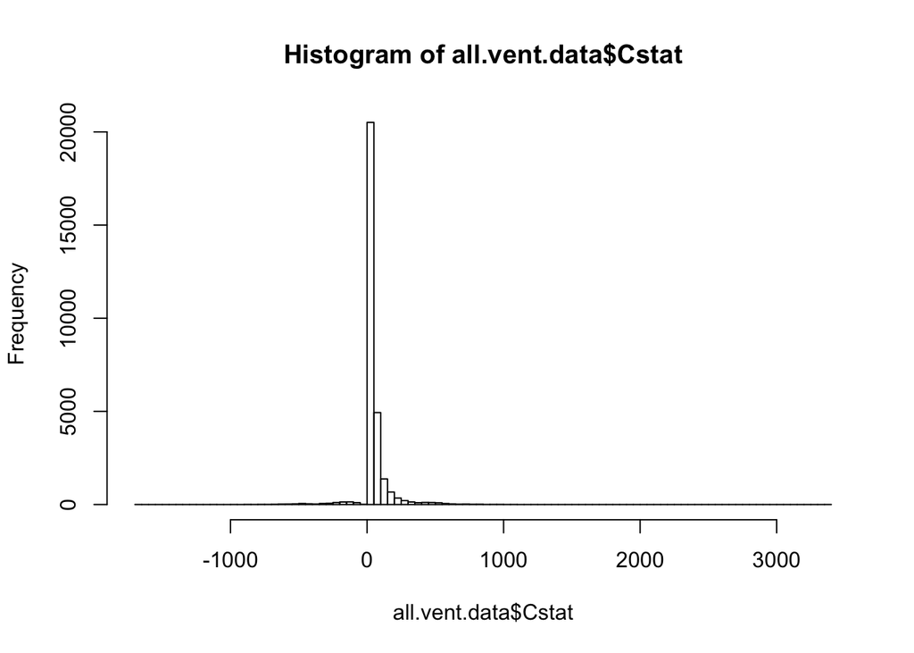

```r
hist(all.vent.data$Cstat, breaks  = 100)
```

We can zoom in on this by dictating the scale:

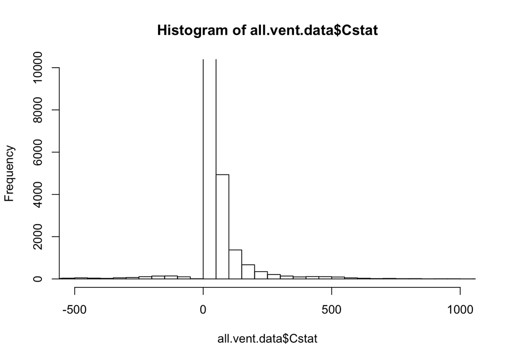

```r
hist(all.vent.data$Cstat, breaks= 100, xlim = c(-500, 1000), ylim = c(0,10000))
```

* Interpret

Let us find which values are responsible and put them in a new variable. This is done with the `which` function which takes a logical argument and return the rows of a data frame which satisfy the conditions.

```r
bad_data <- which(all.vent.data$Cstat < 0)
head (all.vent.data[bad_data, ], 15) #look at the top 15 'bad' rows
```

|  | Hospital_No | Ventilator.hour | PlateauPress | PEEP.cmH20 | TidalVol.ml | index | Sex | Height | Weight | Cstat |
| --- | --- | --- | --- | --- | --- | --- | --- | --- | --- | --- |
| 9617 | F00008354 | 17 | 7 | 10 | 487 | 1 | Female | 165 | 74.3 | -162.3333 |
| 9627 | F00008354 | 27 | 5 | 8 | 494 | 1 | Female | 165 | 74.3 | -164.6667 |
| 9629 | F00008354 | 29 | 6 | 8 | 469 | 1 | Female | 165 | 74.3 | -234.5000 |
| 9631 | F00008354 | 31 | 6 | 8 | 499 | 1 | Female | 165 | 74.3 | -249.5000 |
| 9645 | F00008354 | 45 | 6 | 10 | 489 | 1 | Female | 165 | 74.3 | -122.2500 |
| 9646 | F00008354 | 46 | 7 | 8 | 487 | 1 | Female | 165 | 74.3 | -487.0000 |
| 9649 | F00008354 | 49 | 5 | 10 | 471 | 1 | Female | 165 | 74.3 | -94.2000 |
| 3752 | F00003579 | 2 | 7 | 10 | 406 | 6 | Female | 158 | 86.1 | -135.3333 |
| 3763 | F00003579 | 13 | 5 | 7 | 424 | 6 | Female | 158 | 86.1 | -212.0000 |
| 3765 | F00003579 | 15 | 6 | 8 | 471 | 6 | Female | 158 | 86.1 | -235.5000 |

[output cut: 5 more lines]

- Clean

What do you think are the causes of these issues?

This is unique to the data set that is being studied. [ We will not cover this today ]

### Annotation and Version Control

If you are working on a project for a while your engagement with it will wax and wane as priorities come and go.

After a lull there is nothing more frustrating than trying to figure out what you did in the past just by staring at line upon line of impenetrable code that you cobbled together with brute force and Google searches.

The `#` marker allows for free text around the code which the `R` console ignores.

Another issue is version control - keeping track of changes, especially if you are collaborating, is a nightmare in any document write up.

The best way around this is to use **GitHub**. This is a whole other topic.

My favourite way is to use a document called a *Markdown* file.

Markdown files allow you to annotate around your `R` code allowing you to explain your work and incoporate snippets of code. You can dictate what the reader sees (so it’s not all code). It generates workflow which can be re-applied to other data.

This was written in Markdown.

## Summary

**You can now**

- **Manipulate variables in `R`**
- **Import data into data frames from CSV files**
- **Join different data frames using a common element**
- **Index your data frame to keep track of groups**
- **Slice elements of your data**

## Resources and References

**Courses**

- Cambridge Bioinformatics Training via Cambridge Training

**Online courses**

- [Code School](https://www.codeschool.com/courses/try-r) - Free (for now)
- Coursera (££££)
- [EdX](https://www.edx.org/course/introduction-r-data-science-microsoft-dat204x-2) (£)

**Books**

- *Statistics: An Introduction using R 2nd Edition* Michael J Crawley (Wiley 2015) ISBN 978-1-118-94109-6
- [Hands-On Programming with R](https://rstudio-education.github.io/hopr/) Garrett Grolemund. [Free R bookdown (eBook)]

**Websites**

- StackOverflow
- You Tube (search for Hadley Wickham)

**Good luck!**

`(c) R Samanta 2018` : Cambridge SMaRT Course